# seqbench: Anytime-Valid Sequential Benchmarking of Algorithms in R

Algorithm comparisons are run as sequential experiments: results are inspected as instances are solved, budgets are adapted and the study stops when the outcome looks settled. Fixed-sample tests lose their guarantees under this use. The seqbench package maintains a confidence sequence for the mean paired difference of losses, valid at data-dependent stopping times, and reads it against a pre-registered margin of practical equivalence. It declares one algorithm relevantly better, the two equivalent, or the comparison inconclusive within its budget, all at one error level. In a simulation study with 2,000 replications per cell, the distribution-free boundaries never exceeded 0.45% false declarations, while a repeatedly inspected t-test reached 38%; a Gaussian confidence sequence given the true variance needed 1.4 to 21 times fewer instances. Applications to vehicle routing heuristics, vaccination strategies on contact networks and community detection show the workflow and its costs.

André Leite https://castlab.org (Universidade Federal de Pernambuco) , Raydonal Ospina https://castlab.org (Universidade Federal da Bahia) , Cristiano Ferraz https://castlab.org (Universidade Federal de Pernambuco)  
2026-10-23

## 1 Introduction

Algorithm comparisons in optimisation, machine learning, operations research and computational statistics are rarely fixed-sample experiments. Instances are run in batches; intermediate results are inspected; more instances are added where the outcome looks close; the study stops when one method “clearly” dominates or when the budget runs out. Each of these habits invalidates a fixed-sample test. Inspecting a $t$-test after every instance and stopping at the first rejection inflates the type-I error without bound (Armitage et al. 1969); the simulation study of Section 5 measures 38% false declarations at a nominal 5% in one of its scenarios. The problem is old and well understood in clinical trials, but the benchmarking literature mostly ignores it. Best-practice guides recommend statistical tests (Bartz-Beielstein et al. 2020; Eimer et al. 2025) but not sequential ones, and the racing methods used in algorithm configuration (Birattari et al. 2002; López-Ibáñez et al. 2016) inspect repeatedly by design without controlling the error of the final comparison.

The statistical tool that repairs this is the confidence sequence (Howard et al. 2021; Ramdas et al. 2023): a sequence of sets $C_t$ with $P(\forall t \ge 1: \mu \in C_t) \ge 1-\alpha$, which remains valid at every data-dependent stopping time. Waudby-Smith and Ramdas (2024) give tight confidence sequences for the mean of bounded random variables by betting; Choe and Ramdas (2024) use confidence sequences to compare two forecasters; Arnold et al. (2026) build sequential model confidence sets. In R, safestats (Ly et al. 2024, 2026) implements anytime-valid $t$-tests and their confidence sequences, and seqcomp (Alasgarli 2026) compares probabilistic forecasts sequentially.

seqbench packages this machinery into a *protocol for benchmarking two algorithms*. Its contributions are practical rather than methodological: an explicit population estimand; pairing by instance with seeds treated as a cluster; a pre-registered margin of practical equivalence turned into a three-way decision rule that inherits the error control of the confidence sequence; cost accounting, with an inconclusive outcome that is never converted into a decision; and a result contract that reports what was assumed and what was consumed. We are explicit about what this does not buy. The error control is a margin rule applied to an existing confidence sequence, and, as Section 5 shows, the distribution-free boundaries pay a substantial price in instances relative to a Gaussian sequence that knows the variance. The package makes that price visible.

Section 2 states the problem and its assumptions, Section 3 the protocol and its guarantee, Section 4 the package, Section 5 the simulation study and Section 6 three applications. Section 7 discusses where the protocol applies, and Section 8 its limitations.

## 2 The comparison as a sequential experiment

### 2.1 Estimand

Let $P$ be a population of problem instances and $S$ a distribution of seeds (random restarts, initialisations, stochastic replications). Running algorithm $k \in \{A, B\}$ on instance $i$ with seed $s$ yields a loss $L_k(i, s)$, smaller being better; the loss is the user’s choice and the package does not interpret it. The paired difference is $D(i, s) = L_A(i, s) - L_B(i, s)$, and the estimand is the population mean

$$\mu = E_{i \sim P}\big[E_{s \sim S}[D(i, s)]\big].$$

A negative $\mu$ favours A. This is what “A is better than B on problems like these” means. It is not the mean over a fixed benchmark suite, a finite-population target for which sequential inference would sample without replacement (Waudby-Smith and Ramdas 2020), nor a probability of winning; both are legitimate targets and neither is addressed here.

### 2.2 Practical relevance

A margin $\delta > 0$, in loss units, is fixed before any data are seen and partitions the parameter space into three hypotheses that cover the real line (Table 1).

Table 1: Table 2: The three hypotheses defined by the margin.

| Hypothesis | Condition | Reading |
| --- | --- | --- |
| $H_A$ | $\mu &lt; -\delta$ | A is relevantly better |
| $H_0$ | $&amp;#124;\mu&amp;#124; \le \delta$ | practically equivalent |
| $H_B$ | $\mu &gt; \delta$ | B is relevantly better |

The margin is a domain decision (one percentage point of accuracy, one percentage point of optimality gap, one percentage point of a population infected), recorded with the design and never tuned after inspection. This is the reading of a confidence interval used by equivalence testing (Schuirmann 1987; Lakens 2017) and by Bayesian regions of practical equivalence (Benavoli et al. 2017), made anytime-valid.

### 2.3 Assumptions

- **(A1) Independent instances.** Instances are drawn independently from $P$, and the order in which they are run does not depend on their losses.
- **(A2) Seeds fixed by design.** The number of seeds of an instance and their values are chosen without looking at any loss of that instance; seeds are drawn from $S$.
- **(A3) Bounded losses.** Both losses lie in a known interval $[\ell_{lo}, \ell_{hi}]$, so $D \in [a, b] = [\ell_{lo} - \ell_{hi}, \ell_{hi} - \ell_{lo}]$.
- **(A4) No adaptive reuse.** An instance whose losses were observed does not receive new seeds and does not reappear.

Let $\bar D_t$ be the seed-averaged difference of the $t$-th instance and $X_t = (\bar D_t - a)/(b - a) \in [0, 1]$. Under (A1)–(A4), $E[X_t \mid \mathcal F_{t-1}] = \nu = 1/2 + \mu/(b-a)$ for every $t$, where $\mathcal F_{t-1}$ contains everything observed before instance $t$: the instance is a fresh draw from $P$ (A1), and given the instance its seeds are fresh draws from $S$ whose number may depend on the past but not on the instance’s own losses (A2). This conditional-mean condition is all the confidence sequences below require. The $X_t$ need not be identically distributed (the number of seeds may vary), and arbitrary dependence between the two algorithms, and across the seeds of an instance, is allowed. (A4) is what makes (A2) enforceable: adding seeds to an instance after seeing its losses makes $X_t$ depend on its own outcome. The sequential unit is therefore the instance, not the evaluation.

Timeouts and failed runs must be resolved before the data reach the package. A penalised outcome (PAR-$k$, the cutoff time times $k$ for unfinished runs, Hutter et al. 2009) keeps the loss bounded and changes the estimand to the mean penalised loss; censoring keeps the estimand and breaks boundedness. The package takes the first route and records the choice as the user’s. Truncating an unbounded loss at a cutoff is the same kind of choice, and it also changes the estimand. Where a bound holds by construction, as for the relative gap to a lower bound or an attack rate (Section 6), no such choice is needed.

## 3 The protocol and its guarantee

### 3.1 Confidence sequences for bounded means

On the $[0, 1]$ scale the package offers three confidence sequences of Waudby-Smith and Ramdas (2024), all with the time-uniform guarantee under the conditional-mean condition above: the predictable-plug-in Hoeffding sequence (deterministic width; distribution-free and very conservative), the predictable-plug-in empirical-Bernstein sequence (variance-adaptive) and the hedged betting sequence (the default and the tightest of the three). A fourth valid option, `"bernstein_declared"`, is a predictable-plug-in Bennett sequence that takes a declared upper bound on the standard deviation of the paired difference; its coverage holds only if the declaration is true, and the declaration is recorded in the result as a fifth assumption. A last option, `"naive_fixed"`, is the fixed-sample $t$ interval recomputed after every instance. It is *not* a confidence sequence, is flagged invalid in every output, and exists only as the negative control of Section 5. Because every set of one confidence sequence contains $\nu$ on the same event, the running intersection $C_t^\cap = \bigcap_{s \le t} C_s$ is again a $1-\alpha$ confidence sequence, and the decision rule uses it.

### 3.2 Decision rule

With $C_t^\cap = [L_t, U_t]$ mapped back to loss units, the rules are checked in this order after each instance:

1. inconclusive, with reason `cs_empty`, if $C_t^\cap$ is empty (an event of probability at most $\alpha$; never a decision);
2. A is relevantly better if $U_t < -\delta$;
3. B is relevantly better if $L_t > \delta$;
4. practically equivalent if $-\delta \le L_t$ and $U_t \le \delta$;
5. otherwise continue, unless the budget or the maximum number of instances is exhausted, in which case the outcome is inconclusive, with reason `budget` or `n_max`.

**Proposition (no false declaration, one $\alpha$).** Let $(C_t)$ be a $1-\alpha$ confidence sequence for $\nu$ and let the procedure stop at the first declaration or at an arbitrary stopping time $\tau$, possibly driven by the budget. Then the probability that it issues a false declaration, of any of the three kinds, is at most $\alpha$.

*Proof.* On the event $E = \{\forall t: \nu \in C_t\}$, which has probability at least $1-\alpha$, $\nu \in C_t^\cap$, hence $L_t \le \nu \le U_t$, for every $t$. Each declaration condition then implies the corresponding hypothesis ($U_t < -\delta$ implies $\mu < -\delta$, and so on), so every declaration issued on $E$ is correct, whenever it is issued. The event of a false declaration is therefore contained in $E^c$. $\square$

The proof is one paragraph because the confidence sequence does the work. What the protocol adds is the reading: the three declarations are events on one simultaneous confidence set, so no split of $\alpha$ is needed (two one-sided tests for equivalence need none either, being an intersection–union test), and the guarantee holds at the data-dependent time at which a benchmarker actually stops. “Inconclusive” carries no error: it is the complement of a declaration, and its probability is a design quantity.

### 3.3 Planning

For the Hoeffding sequence the half-width $w_t$ is deterministic. On the coverage event a comparison run with that boundary has issued the correct declaration by $t^*(g) = \min\{t : 2 w_t < g\}$, where $g$ is the distance from $\nu$ to the nearest threshold on the $[0,1]$ scale; $t^*$ depends only on $(\alpha, \delta, \text{bounds})$ and a target distance, and `planning_horizon()` returns it. The guarantee is distribution-free but belongs to the Hoeffding boundary, and it is very conservative: at $\delta = 0.02$, bounds $[0, 1]$ and a distance of 0.02, $t^* =$ 458,244 instances, against a median of 388 for the betting boundary in the corresponding cell of Section 5. Given a planning value of the standard deviation of the paired difference, `planning_horizon()` returns instead the horizon of the empirical-Bernstein width with that variance plugged in. This is an approximation, not a bound. In the regimes of Section 5 the median stopping time was about one half of it for the empirical-Bernstein boundary and about one quarter for the betting boundary; the truncated-bet analysis there explains why.

## 4 The package

### 4.1 Workflow

```r
library(seqbench)
set.seed(1)
design <- comparison_design(alpha = 0.05, margin = 0.02, bounds = c(0, 1),
                            boundary = "betting", budget = 800)
state  <- initialize_comparison(design)

# one row per (instance, seed); here A loses 0.05 more than B on average
la <- runif(400, 0.40, 0.80)
losses <- data.frame(instance = 1:400, seed = 1L, loss_a = la,
                     loss_b = la - 0.05 + runif(400, -0.17, 0.17))
state  <- update_comparison(state, losses)
stopping_decision(state)
```

```
[1] "B"
attr(,"reason")
[1] "declaration"
```

```r
glance(state)
```

```
# A tibble: 1 × 12
  boundary valid alpha margin n_instances n_evaluations  cost estimate
  <chr>    <lgl> <dbl>  <dbl>       <int>         <int> <dbl>    <dbl>
1 betting  TRUE   0.05   0.02         344           344   344   0.0440
# ℹ 4 more variables: lower <dbl>, upper <dbl>, decision <chr>,
#   stopping_reason <chr>
```

`update_comparison()` is incremental: rows of new instances can be fed at any time and in any batch size, and the seeds of an instance are averaged into one observation. The procedure stops at the first instance that triggers a declaration and refuses data after it, because the pre-registered protocol ends there; a warning lists what was not consumed (here, the instances after the declaration). `comparison_report()` (also `summary()`) returns the result contract, `tidy()` the trajectory (one row per instance with the interval, its running intersection, the cost and the decision at that time), `glance()` a one-row summary, and `autoplot()` the confidence sequence against the number of instances with the equivalence band (Figure 1).

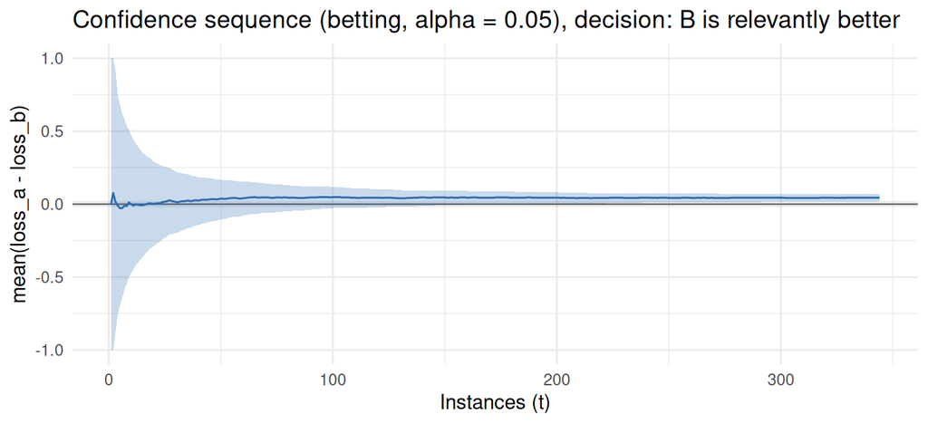

Figure 1: Output of autoplot() for the comparison above: running confidence sequence for the mean paired difference (ribbon), estimate (line) and equivalence band [-0.02, 0.02] (grey). The procedure stops when the whole ribbon is above the band.

```r
ggplot2::autoplot(state)
```

### 4.2 The result contract

Every comparison reports the estimand (as a sentence), the estimate, the current confidence sequence, the boundary and its validity flag, the assumptions in words (four, or five with a declared variance bound), the decision and stopping reason, diagnostics (instances, evaluations, losses at the bounds, an empty-set flag), the resources consumed against the budget, the instance and seed identifiers in the order observed, and the package and R versions. The intent is that a reader can audit a decision without rerunning it.

### 4.3 Refusals

The package never converts invalid input into a valid-looking result. A loss outside the declared bounds is an error, not a clipped value; a missing loss is an error, not a dropped row; a negative or infinite cost is an error; a duplicated (instance, seed) pair is an error; an instance that reappears after its losses were observed is an error whose message explains (A4); `paired = FALSE` is an error stating that unpaired designs are not implemented; and updating after a terminal decision is an error too.

### 4.4 Implementation notes

Each boundary is a small state machine with sufficient statistics, exposed through three kernels that other packages can reuse: `boundary_init()` creates the state, `boundary_update()` absorbs one observation and `boundary_interval()` reads the current confidence set. The betting boundary keeps the hedged log-capital on a grid of candidate means (1,001 points by default); its confidence set is the set of means at which the capital is below $1/\alpha$, which Waudby-Smith and Ramdas (2024) show to be an interval. The package reports the outer edges of the grid cells that contain the endpoints, so that the reported set contains the exact one, and refines both endpoints on the exact capital once per call of `update_comparison()`; a nonempty set narrower than one grid cell is located by minimising the exact capital rather than reported as empty.

Decisions do not depend on the grid. Because the confidence sets are intervals, each rule of the decision rule in Section 3 is equivalent to a statement about the two thresholds: B is declared when $+\delta$ has left the running set and the set lies above it, and so on. The package therefore tracks the exact capital at the two thresholds, which costs $O(1)$ per instance, and records on which side of a threshold the set lies when the capital excludes it; every later set is contained in that one, so the side never changes. The per-instance cost is linear in the grid size and does not grow with the length of the stream. A stream of 8,000 instances exactly at the margin, which never decides, takes about 3.5 s on a 2015-era desktop processor (Intel Core i5-6500, R 4.6.1), against about 34 s with version 0.1.0.

## 5 Simulation study

### 5.1 Design

The study was frozen before results were available: configuration files are dated and never edited, and changes are new files. Its analysis script was written and tested on a three-replication smoke run before the study ran. All code is in the `experiments/` directory of the package repository.[^1] Losses are generated as $L_A = u_i + \eta_{is}$ and $L_B = u_i' + \eta'_{is} - \mu + e_{is}$, with an instance effect $u_i \sim U(0.45, 0.70)$ shared by both algorithms when paired ($u_i' = u_i$) and drawn independently otherwise, seed noise $\eta, \eta' \sim U(-h_{seed}, h_{seed})$ and comparison noise $e \sim U(-h, h)$; then $E[L_A - L_B] = \mu$ exactly, all losses lie in $[0.047, 0.903] \subset [0, 1]$, and the standard deviation of the per-instance difference is known. The baseline grid crosses $\mu \in \{0, 0.01, 0.02, 0.05, 0.10, 0.20\}$ (null, true equivalence, exactly at the margin, moderate, large and very large effects) with $\text{sd}(D) \in \{0.03, 0.10\}$, with $\alpha = 0.05$, $\delta = 0.02$, bounds $[0, 1]$ and a budget of 2,000 instances. Two ablations use the high noise level: unpaired instances, and five seeds per instance with seed noise $h_{seed} = 0.03$. Each of the 24 cells has 2,000 replications, and every method sees the same simulated stream in a given replication (seeded by cell and replication only), so method comparisons are paired.

Two amendments, frozen on 2026-09-26 after an external review and run with the same methods and replication count, add 14 cells with negative effects and with effects 0.005 and 0.01 away from a threshold ($\mu \in \{-0.20, -0.05, -0.025, -0.015, 0.015, 0.025, 0.03\}$, both noise levels), and 12 seed-cluster cells with an instance-specific differential effect (see “Pairing and seed clusters” below). One amended cell ($\mu = -0.20$, high noise) is invalid by construction: its losses for B reach 1.07, and the package refused every replication rather than clip. It is reported as such and excluded; the other 13 cells cover the negative direction.

Eight procedures are compared: the three distribution-free boundaries and the invalid control; fixed-sample $t$ intervals at $n = 100$, $500$ and $2{,}000$ instances with the same three-way margin rule and no adaptation; and the anytime-valid confidence sequence of the sequential $t$-test of safestats (Ly et al. 2024; `saviTTest()`, Ly et al. 2026) with the same running intersection and margin rule. Its design is fixed before the stream with the *true* standard deviation of the data-generating process, an oracle that favours safestats, which assumes Gaussian data while ours are sums of uniforms.

The metrics are false declarations (a declaration that contradicts the truth; at $\mu = \delta$ the truth is “equivalent”), coverage failure (the true mean leaves the reported running intersection at some time up to stopping), the proportion of inconclusive outcomes, and the number of instances consumed. Rates carry Wilson intervals, medians percentile bootstrap intervals over replications, and ratios of medians paired bootstrap intervals. With 2,000 replications the Monte Carlo standard error of a rate near 0.05 is 0.005, and zero observed events give an upper Wilson bound of 0.0019.

### 5.2 Validity

Table 3 gives, for each procedure, the largest false-declaration rate and the largest coverage-failure rate over the 24 cells.

Table 3: Table 4: Maximum rates over the 24 cells (2,000 replications each), with the cell of the maximum false-declaration rate and its 95% Wilson interval.

| Procedure | max false declaration [95% Wilson] | max coverage failure |
| --- | --- | --- |
| betting | 0.0045 ($\mu = 0.02$, unpaired) [0.0024, 0.0085] | 0.0145 |
| empirical Bernstein | 0.0015 ($\mu = 0.02$, unpaired) [0.0005, 0.0044] | 0.0025 |
| Hoeffding | 0.0000 [0.0000, 0.0019] | 0.0000 |
| fixed $n = 100$ | 0.0310 ($\mu = 0.02$) [0.0243, 0.0395] | 0.0610 |
| fixed $n = 500$ | 0.0270 ($\mu = 0.02$) [0.0208, 0.0351] | 0.0560 |
| fixed $n = 2000$ | 0.0355 ($\mu = 0.02$, unpaired) [0.0282, 0.0445] | 0.0640 |
| safestats CS, oracle sd | 0.0250 ($\mu = 0.02$) [0.0190, 0.0328] | 0.0495 |
| naive fixed (invalid) | 0.3800 ($\mu = 0.02$) [0.3590, 0.4015] | 0.6195 |

The three distribution-free boundaries stay far inside their nominal level. Their few false declarations are concentrated at the exact margin, where “equivalent” is the only correct answer and a superiority declaration is a legitimate $\alpha$-event. The fixed-sample tests and the Gaussian sequence sit near their nominal level. The repeatedly inspected $t$-test issues a false declaration in 38% of the runs at the margin, 20% under true equivalence and 17% under the null, and its interval misses the truth at some inspection in up to 62% of the runs: this is the behaviour of a benchmark that peeks. In 10 of its 24 cells the lower Wilson bound of the false-declaration rate is above $\alpha$.

### 5.3 Cost

Table 5: Table 6: Median instances to stopping, baseline cells with $\text{sd}(D) = 0.10$, 2,000 replications. A superscript gives the percentage of inconclusive runs when above 0.5%; ``budget’’ marks cells where at least 90% of the runs exhausted the 2,000 instances. For the valid sequential procedures the bootstrap 95% intervals of the medians are within 6% of the reported value.

| Procedure | $\mu = 0$ | $\mu = 0.01$ | $\mu = 0.02$ | $\mu = 0.05$ | $\mu = 0.1$ | $\mu = 0.2$ |
| --- | --- | --- | --- | --- | --- | --- |
| betting | 496 | 1066$^{10\%}$ | budget | 272 | 100 | 44 |
| empirical Bernstein | 920 | 1807$^{36\%}$ | budget | 520 | 190 | 83 |
| Hoeffding | budget | budget | budget | budget | budget | 371 |
| fixed $n = 100$ | budget | budget | budget | 100$^{16\%}$ | 100 | 100 |
| fixed $n = 500$ | 500$^{1\%}$ | 500$^{40\%}$ | budget | 500 | 500 | 500 |
| fixed $n = 2000$ | 2000 | 2000$^{1\%}$ | budget | 2000 | 2000 | 2000 |
| safestats CS, oracle sd | 273 | 760$^{9\%}$ | budget | 83 | 27 | 17 |
| naive fixed (invalid) | 128 | 168 | 1090$^{47\%}$ | 25 | 8 | 4 |

Three readings. First, adaptation pays. The betting sequence resolves the null in a median of 496 instances and the moderate effect in 272, whereas a fixed sample of 100 is inconclusive in 96% of the runs under the null and a fixed sample of 500 in 40% at $\mu = 0.01$. Second, the distribution-free boundaries are ordered as expected: empirical Bernstein needs 1.7 to 2.0 times the instances of betting, and Hoeffding resolves only the very large effect within the budget. Third, and this is the number a benchmarker should see before choosing, the Gaussian sequence with a known variance needs 0.27 to 0.71 of the instances of the betting sequence at this noise level and 0.05 to 0.14 at the low noise level (Table 7), that is, 1.4 to 21 times fewer. The truncated-bet analysis below explains the mechanism, and Section 8 draws the consequence.

Table 7: Table 8: Ratio of median instances, safestats CS over betting, with the paired bootstrap 95% interval, baseline cells.

| $\text{sd}(D)$ | $\mu = 0$ | $\mu = 0.01$ | $\mu = 0.05$ | $\mu = 0.1$ | $\mu = 0.2$ |
| --- | --- | --- | --- | --- | --- |
| 0.03 | 0.077 (0.077–0.080) | 0.103 (0.099–0.109) | 0.047 (0.047–0.047) | 0.072 (0.072–0.072) | 0.136 (0.136–0.136) |
| 0.10 | 0.550 (0.536–0.562) | 0.713 (0.683–0.743) | 0.305 (0.297–0.312) | 0.270 (0.270–0.273) | 0.386 (0.378–0.386) |

### 5.4 Pairing and seed clusters

Table 9: Table 10: Betting boundary, $\text{sd}(D) = 0.10$: ratio of median instances and of mean evaluations (both algorithms, all seeds) relative to the paired single-seed design.

| Ablation | $\mu = 0$ | $\mu = 0.01$ | $\mu = 0.05$ | $\mu = 0.1$ | $\mu = 0.2$ |
| --- | --- | --- | --- | --- | --- |
| unpaired, instances | 1.46 | 1.79 | 1.09 | 1.01 | 1.02 |
| unpaired, evaluations | 1.55 | 1.36 | 1.15 | 1.03 | 1.02 |
| five seeds, instances | 0.82 | 0.72 | 0.94 | 0.97 | 1.00 |
| five seeds, evaluations | 3.92 | 3.36 | 4.66 | 4.85 | 4.95 |

Pairing by instance costs nothing and saves up to 44% of the instances in the hard cells: at $\mu = 0.01$ it turns 47% inconclusive runs into 10%. Averaging five seeds per instance saves up to 28% of the *instances* but costs 3.4 to 4.9 times the *evaluations*. In this design the instance effect cancels exactly under pairing, so seed averaging only reduces independent seed noise, and its benefit is confined to the cells where the variance matters at all (see the truncated-bet analysis below).

The cluster amendment adds to the paired difference an instance-specific term $v_i \sim U(-w, w)$ shared by all seeds of instance $i$, so that the differences within an instance are positively correlated and an analysis by row is genuinely invalid. With $w = 0.05$ the intra-instance correlation is 0.07 and the design effect of five seeds is 1.3. Table 11 compares the correct analysis (one sequential unit per instance) with pseudoreplication (every (instance, seed) row fed as its own instance).

Table 11: Table 12: Seed clusters with an instance-specific differential effect ($w = 0.05$), 2,000 replications: median instances to stopping (mean evaluations of both algorithms in parentheses; a superscript gives the percentage of inconclusive runs when above 0.5%) and the largest coverage-failure rate over the three effect sizes. For pseudoreplication the instances are the rows divided by five.

| Procedure | Seeds | $\mu = 0$ | $\mu = 0.01$ | $\mu = 0.05$ | Max. cov. failure |
| --- | --- | --- | --- | --- | --- |
| betting | 1 | 518 (553) | 1102$^{14\%}$ (1188) | 275 (284) | 0.30% |
| betting | 5 | 413 (2108) | 778 (3953) | 257 (1298) | 0.05% |
| betting, pseudoreplication | 5 | 107 (573) | 229$^{19\%}$ (1218) | 55 (283) | 1.20% |
| empirical Bernstein | 1 | 937 (970) | 1816$^{39\%}$ (1716) | 530 (537) | 0.00% |
| empirical Bernstein | 5 | 811 (4114) | 1564$^{4\%}$ (7857) | 500 (2511) | 0.00% |
| fixed $n = 2000$ | 1 | 2000 (2000) | 2000$^{1\%}$ (2000) | 2000 (2000) | 5.40% |
| fixed $n = 2000$ | 5 | 2000 (10000) | 2000 (10000) | 2000 (10000) | 5.50% |

The result is negative, and we report it as measured. Pseudoreplication produced 0 false declarations in 12,000 runs, and its coverage failure rose only to 1.2% with five seeds, against 0.05% for the correct analysis: a design effect of 1.3 is absorbed by the slack of the betting boundary documented in the coverage audit below. Its cost equals that of a single-seed analysis because it consumes the same rows under another label. The correct five-seed analysis saves 7% to 29% of the *instances* against one seed and costs 3.3 to 4.6 times the *evaluations*, as in the first ablation. The conclusion for practice is unchanged. Seeds are a cluster, not replications, and averaging them is worth its price only when instances are expensive relative to evaluations. The guarantee did not visibly break here because the correlation was mild, not because pseudoreplication is safe; the vaccination application of Section 6 measures a strong correlation.

### 5.5 Why the cost is what it is: the truncated-bet regime

The betting sequence bets a predictable fraction $\tilde\lambda_t = \sqrt{2\log(2/\alpha)/(\hat\sigma^2_{t-1}\, t \log(t+1))}$, truncated at $c/m$ and $c/(1-m)$ for the candidate mean $m$; with $c = 1/2$ the cap is close to 1 near $m = 1/2$. While $\tilde\lambda_t$ exceeds the cap, that is, while $t\log(t+1) < 2\log(2/\alpha)/(\hat\sigma^2 \cdot \text{cap}^2)$, the bet is constant, and for small variance the log-capital at a candidate at distance $g$ from $\nu$ grows by about $\text{cap} \cdot g$ per instance. With the hedging weight $1/2$, a threshold is excluded once that log-capital reaches $\log(2/\alpha)$, so the stopping time is approximately

$$\tau \approx \frac{\log(2/\alpha)}{\text{cap}\cdot g} = \frac{\log(2/\alpha)\,(b-a)}{\text{cap}\cdot\big|\,|\mu| - \delta\,\big|},$$

linear in the inverse distance to the nearest threshold and *independent of the variance*. Table 13 compares this prediction with the observed medians.

Table 13: Table 14: Betting boundary: median instances observed and predicted by the truncated-bet approximation, for $\text{sd}(D) = 0.03$ (crossover at $t \approx 4,060$) and $0.10$ (crossover at $t \approx 481$).

| $\mu$ | distance | observed, sd 0.03 | predicted | observed, sd 0.10 |
| --- | --- | --- | --- | --- |
| 0.00 | 0.02 | 388 | 369 | 496 |
| 0.01 | 0.01 | 737 | 738 | 1066 |
| 0.05 | 0.03 | 254 | 246 | 272 |
| 0.10 | 0.08 | 97 | 92 | 100 |
| 0.20 | 0.18 | 44 | 41 | 44 |

At the low noise level the prediction is within 7% of the observed median everywhere. At the high noise level it holds where the decision comes before the crossover and degrades to 1.34–1.44 times the prediction where it comes after, when the variance term of the bet becomes active. Figure 2 shows the observed medians against the prediction. A log-log regression of the median stopping time on the distance and the standard deviation over the resolved cells of both boundaries, with a boundary-specific intercept, gives slopes -1.04 (s.e. 0.02) and +0.10 (0.03).

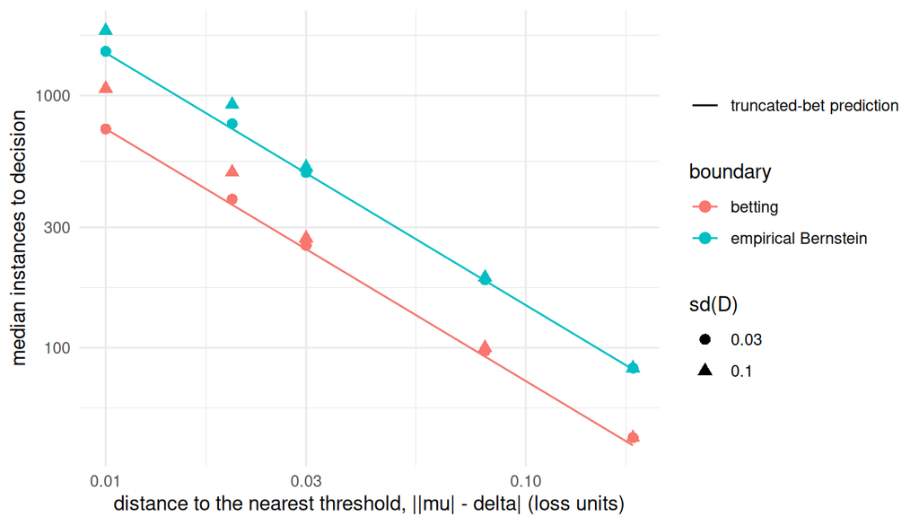

Figure 2: Median instances to decision against the distance to the nearest decision threshold (log-log), betting and empirical-Bernstein boundaries, two noise levels, 2,000 replications per point. Lines: the truncated-bet prediction.

There are two practical consequences. In low-noise benchmarks with a tight margin, halving the distance to the threshold doubles the cost rather than quadrupling it. And the boundary cannot exploit a small variance beyond its bet cap, which is why the Gaussian sequence, whose bet scales with $g/\sigma^2$, is so much faster when $\sigma$ is small. Raising the cap helps at a small, measurable price. In a sweep on the twelve baseline cells (2,000 replications each, same streams), $c = 0.9$ needed 222 instead of 388 instances at the null and 143 instead of 254 at $\mu = 0.05$ for $\text{sd}(D) = 0.03$ (385 and 165 instead of 496 and 272 at $\text{sd}(D) = 0.10$), while the largest false-declaration rate rose from 0.20% to 0.70% and the largest coverage failure from 0.55% to 1.40%, both still far below $\alpha$; $c = 0.99$ gained little more. Coverage is guaranteed for any $c \in (0, 1)$.

### 5.6 Time-uniform coverage without stopping

Coverage in Table 3 is measured up to the stopping time. A separate audit ran each boundary over the full stream of 2,000 instances in the same 24 cells (same seeds, hence the same streams; for the betting boundary the exact capital at the true mean is evaluated, which needs no grid) and recorded whether the true mean ever left the running confidence sequence. Over 2,000 replications per cell the largest failure rate was 1.55% for betting, 0.25% for empirical Bernstein and 0 for Hoeffding, against the nominal 5%. The time-uniform guarantee holds with room to spare, which is the other face of the cost measured above.

### 5.7 Negative effects and effects near the margin

The first amendment fills two gaps of the baseline grid: effects in the direction of A, and effects 0.005 and 0.01 away from a decision threshold ($|\mu| \in \{0.015, 0.025, 0.03\}$ with $\delta = 0.02$). Over its 13 valid cells no distribution-free boundary made a false declaration (0 in 78,000 runs; upper Wilson bound 0.19% per cell), whereas the safestats sequence reached 0.95% and the repeatedly inspected $t$-test 22.8%. Coverage failure up to stopping was at most 0.25% for betting and 0 for the other two boundaries. Table 15 gives the cost.

| $\text{sd}(D)$ | Procedure | $-0.2$ | $-0.05$ | $-0.025$ | $-0.015$ | $0.015$ | $0.025$ | $0.03$ |
| --- | --- | --- | --- | --- | --- | --- | --- | --- |
| 0.03 | betting | 44 | 255 | 1552$^{5\%}$ | 1496$^{4\%}$ | 1497$^{3\%}$ | 1562$^{6\%}$ | 769 |
|  | empirical Bernstein | 83 | 495 | budget | budget | budget | budget | 1503 |
|  | Hoeffding | 372 | budget | budget | budget | budget | budget | budget |
|  | fixed $n = 500$ | 500 | 500 | 500$^{4\%}$ | 500$^{3\%}$ | 500$^{4\%}$ | 500$^{4\%}$ | 500 |
|  | safestats CS, oracle sd | 6 | 12 | 419 | 399 | 404 | 431 | 81 |
| 0.10 | betting | — | 269 | 2000$^{80\%}$ | 2000$^{81\%}$ | 2000$^{79\%}$ | 2000$^{80\%}$ | 1042$^{10\%}$ |
|  | empirical Bernstein | — | 521 | budget | budget | budget | budget | 1755$^{33\%}$ |
|  | Hoeffding | — | budget | budget | budget | budget | budget | budget |
|  | fixed $n = 500$ | 500 | 500 | 500$^{80\%}$ | 500$^{79\%}$ | 500$^{80\%}$ | 500$^{79\%}$ | 500$^{38\%}$ |
|  | safestats CS, oracle sd | 17 | 85 | 2000$^{75\%}$ | 2000$^{76\%}$ | 2000$^{75\%}$ | 2000$^{75\%}$ | 714$^{8\%}$ |

Two readings. The procedures are symmetric in the sign of $\mu$, as they should be: the betting boundary needs 255 and 269 instances at $\mu = -0.05$ against 254 and 272 at $+0.05$. And a distance of 0.005 from a threshold is beyond every procedure at the high noise level, the Gaussian oracle included: safestats is inconclusive in 75%–76% of the runs and betting in 79%–81%. At the low noise level betting resolves these cells in a median of about 1,500 instances with 3% to 6% inconclusive runs, and the Gaussian sequence in about 400. Before the first instance is run, `planning_horizon()` with the true standard deviation returns 6,344 (low noise) and 21,440 (high noise) instances for this distance, both beyond the budget of 2,000: this is where a benchmarker should learn that a distance of 0.005 is not a question the budget can answer.

## 6 Applications

### 6.1 Vehicle routing heuristics

A distribution planner must choose a constructive heuristic for the capacitated vehicle routing problem (Toth and Vigo 2014): the sweep algorithm of Gillett and Miller (1974) (A) or the savings algorithm of Clarke and Wright (1964) (B), both followed by 2-opt inside each route (Croes 1958). Instances follow the generator logic of Uchoa et al. (2017): 50 to 150 customers in the unit square, a central, eccentric or random depot, uniform, clustered or mixed customer positions, unitary, small or large demands, and a capacity giving 4 to 25 customers per route on average. The loss is the relative gap $1 - LB/z$ of the solution cost $z$ to the lower bound $LB = \max\{\text{MST},\ 2\sum_i q_i d_{0i}/Q\}$, the larger of the minimum spanning tree of the depot and customers and the radial bound. It lies in $[0, 1)$ for any feasible solution by construction, so the bounds $[0, 1]$ need no truncation. The margin is one percentage point of gap ($\delta = 0.01$) and the cost is CPU time. The pool mean is $\mu = 0.0533$ (sd 0.048, skewness 0.70): the savings algorithm closes about 5.3 percentage points more of the gap.

On the live stream the betting sequence declared “B is relevantly better” after 189 instances (6.1 CPU seconds), with final interval $[0.010, 0.087]$; empirical Bernstein needed 334. Over 1,000 resampled streams every procedure declared B in 100% of the runs, with no false declaration. The effect is large relative to the margin, so a fixed sample of 100 instances would also have sufficed; the sequential procedures find this out without knowing it in advance, while a cautious fixed sample of 3,000 instances spends 95 CPU seconds against 5.6 for the betting sequence (median 177 instances; empirical Bernstein 347, the pilot-designed Gaussian sequence 24). Coverage failure up to stopping was 0.0% for betting, 0.6% for the Gaussian sequence and 5.5% for the fixed sample of 100, which has a single, nominal 95% interval. Table 17 collects the results of both applications.

### 6.2 Vaccination strategies on contact networks

With the same number of doses, does vaccinating the highest-degree people (degree targeting, B), which needs the full contact network, reduce the final attack rate of an epidemic by a practically relevant amount relative to acquaintance immunisation (Cohen et al. 2003), which vaccinates a random contact of a random person and needs only local information (A)? Both improve on random vaccination in heterogeneous networks (Pastor-Satorras and Vespignani 2002). Instances are networks of 1,000 to 3,000 people drawn from five models (Erdős–Rényi, Barabási–Albert, Watts–Strogatz, stochastic block model with 5 to 20 communities, and power-law Chung–Lu), with $R_0 \sim U(1.5, 3)$, vaccine coverage between 5% and 20%, and five index cases. The epidemic is an SIR process with a fixed infectious period; its final size is exactly the size of the union of the index cases’ clusters in bond percolation on the network without the vaccinated (Newman 2002; Kenah and Robins 2007), which is how it is simulated with igraph (Csárdi and Nepusz 2006). The loss is the attack rate, the fraction of the population infected, in $[0, 1]$ by construction, and the margin is one percentage point ($\delta = 0.01$). Each instance has five seeds, independent epidemics in which both strategies share the percolated network and the order from which index cases are taken (common random numbers), so the pairing is by (instance, seed) and the seeds of a network form a cluster.

The pool is not Gaussian: the per-network difference has skewness 1.07 with one seed and 3.3% exact ties (both strategies stop the epidemic, or both fail to), and the differences of the five simulations of a network are strongly correlated, with an intra-network correlation of 0.71 and a design effect of 3.8. Degree targeting lowers the attack rate by $\mu = 0.133$ on average, far beyond the margin. On the live stream the five-seed betting analysis declared “B is relevantly better” after 62 networks (310 paired simulations). Over the resampled streams every procedure declared B in every run. The informative comparison is the cost of the two designs: the five-seed analysis needed a median of 64 networks and the one-seed analysis 65, at 3.4 against 0.7 CPU seconds. Averaging five epidemics per network bought nothing, because the betting sequence decides here in its truncated-bet regime, where the stopping time does not depend on the variance (Section 5, truncated-bet regime); one simulation per network, and more networks, is the better design. The invalid pseudoreplication analysis stopped after a median of 65 simulations, about 13 networks, and its interval missed the truth in 0.4% of the streams against 0.0% for the correct analysis. With an effect 13 times the margin this did not produce false declarations, but its interval treats correlated simulations as independent evidence, and no guarantee covers it. The pilot-designed Gaussian sequence did not lose coverage on these data.

Table 17: Table 18: Applications, 1,000 streams resampled from each frozen pool: rates of correct declarations, false declarations and inconclusive outcomes, coverage failure up to stopping, median instances to stopping and mean CPU seconds consumed. For pseudoreplication the median counts simulations, not networks.

| Application | Procedure | correct | false | inconcl. | cov. failure | median $n$ | CPU s |
| --- | --- | --- | --- | --- | --- | --- | --- |
| routing | betting | 100.0% | 0.0% | 0.0% | 0.0% | 177 | 5.6 |
|  | empirical Bernstein | 100.0% | 0.0% | 0.0% | 0.0% | 347 | 11.0 |
|  | fixed $n = 100$ | 100.0% | 0.0% | 0.0% | 5.5% | 100 | 3.2 |
|  | fixed $n = 3000$ | 100.0% | 0.0% | 0.0% | 5.6% | 3000 | 95.0 |
|  | safestats CS, pilot sd | 100.0% | 0.0% | 0.0% | 0.6% | 24 | 0.8 |
| epidemic, 5 seeds | betting | 100.0% | 0.0% | 0.0% | 0.0% | 64 | 3.4 |
|  | empirical Bernstein | 100.0% | 0.0% | 0.0% | 0.0% | 124 | 6.5 |
|  | fixed $n = 100$ | 100.0% | 0.0% | 0.0% | 4.7% | 100 | 5.2 |
|  | fixed $n = 3000$ | 100.0% | 0.0% | 0.0% | 5.1% | 3000 | 156.7 |
|  | safestats CS, pilot sd | 100.0% | 0.0% | 0.0% | 0.0% | 47 | 2.5 |
|  | betting, pseudoreplication (invalid) | 100.0% | 0.0% | 0.0% | 0.4% | 65 | 0.7 |
| epidemic, 1 seed | betting | 100.0% | 0.0% | 0.0% | 0.0% | 65 | 0.7 |
|  | empirical Bernstein | 100.0% | 0.0% | 0.0% | 0.0% | 123 | 1.3 |
|  | fixed $n = 100$ | 100.0% | 0.0% | 0.0% | 5.9% | 100 | 1.0 |
|  | fixed $n = 3000$ | 100.0% | 0.0% | 0.0% | 4.6% | 3000 | 31.3 |
|  | safestats CS, pilot sd | 100.0% | 0.0% | 0.0% | 0.0% | 58 | 0.6 |

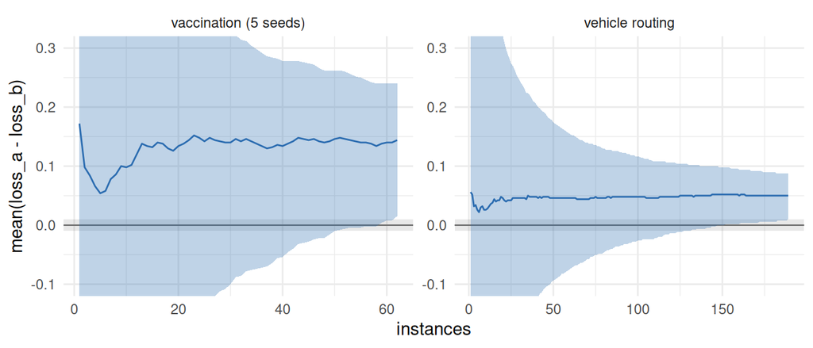

Figure 3: Live runs of the betting sequence on fresh instances in generation order: running confidence sequence for the mean paired difference against the number of instances (networks, for the epidemic with five seeds each), with the equivalence band. Left: acquaintance minus degree targeting, attack rate. Right: sweep minus savings, relative gap. The vertical axis is cut at [-0.1, 0.3]; the early intervals are wider.

### 6.3 Louvain versus Leiden

The third application, frozen on 2026-09-25, compares two community-detection algorithms whose outputs tie, cluster and skew. Instances are stochastic block models with 3 to 6 blocks of unequal sizes, 80 to 300 nodes and per-instance mixing; A is `cluster_louvain()` of igraph, B `cluster_leiden()` run to convergence on modularity, both with the instance’s seed; the loss is $1 - Q$ with bounds $[0, 1.5]$, and $\delta = 0.01$ (one modularity point). Its 100 replications are fresh streams of up to 6,000 instances, so the truth is known only through a Monte Carlo reference of 5,000 instances, which puts the mean difference at 0.0055 in favour of Leiden, inside the margin. The per-instance differences are far from Gaussian: 40% exact ties, Louvain ahead in 3.5% of the instances, skewness 1.8. All four procedures declared practical equivalence in every replication: the betting sequence after a median of 2,533 instances, empirical Bernstein after 5,090, the fixed-sample test at its limit of 6,000, and the safestats sequence after a median of 26. That last number is not a success. On this distribution the Gaussian sequence, designed with a pilot standard deviation, stopped after 4 or 5 instances whenever the first differences were all ties, with an interval that had collapsed to a point, and its running interval excluded the reference mean in 15% of the replications, against none for the two bounded boundaries. The declaration happened to be right because the truth is equivalence, but the guarantee was gone. Algorithm outputs tie, cluster and skew, and a sequence that assumes a model pays for its speed in coverage exactly where the assumption fails.

Two earlier applications, a location-estimator comparison and a knapsack heuristic comparison, remain in `experiments/` with their frozen configurations; they show nothing the three above do not.

## 7 Potential uses

The protocol applies wherever two procedures are compared on a stream of independent units with bounded, paired losses and the cost of each unit matters. We see five families of use.

- **Monte Carlo studies in statistics.** Comparing two estimators, tests or interval procedures by simulation is a benchmark whose instances are i.i.d. by construction, so (A1) holds exactly. The package then answers the question that fixed replication counts leave open: when can the study stop?
- **Operations research and optimisation.** Heuristics, metaheuristics and solver settings compared on an instance generator, as in the routing application of Section 6. A natural loss is a gap to a bound, which is bounded by construction, and the cost column can be CPU time or objective evaluations.
- **Regression testing of numerical software.** A new release of a solver against the previous one on a generator of test problems, inside continuous integration: an equivalence declaration is a statement of “no relevant regression” at a known error level, and an inconclusive outcome is a reason to look, not a pass.
- **Simulation-based policy evaluation.** Epidemic interventions (Section 6), traffic control, inventory and supply-chain policies evaluated in stochastic simulators or digital twins. Scenarios drawn from a prior are the instances, stochastic replications are the seeds, and outcomes such as attack rates, service levels or fill rates are bounded proportions.
- **Machine learning evaluation.** Two models scored on i.i.d. test examples with a bounded per-example loss (zero-one loss, a capped log loss, a rubric score of a generated answer), where labelling or grading each example is expensive. Cross-validation folds are not independent instances (Nadeau and Bengio 2003); the protocol applies to a held-out stream, not to folds.

Racing for algorithm configuration (Birattari et al. 2002) is a sequence of such comparisons; one pairwise race with seqbench is valid, but a race among many candidates needs a multiplicity correction or sequential model confidence sets (Arnold et al. 2026).

## 8 Limitations and open problems

**What it costs.** Distribution-free validity for bounded losses is expensive when the losses have a small variance relative to their range: the Gaussian sequence with a known variance needed 7 to 21 times fewer instances at the low noise level. The mechanism is the bet cap analysed in Section 5, and it implies a floor of order $\log(1/\alpha)(b-a)/\big||\mu| - \delta\big|$ instances that does not vanish as the variance shrinks. We conjecture that a floor of this order binds every procedure that is valid for all distributions on $[a, b]$: a small contamination at an endpoint of the range changes the mean while staying almost indistinguishable from the original distribution, which suggests a change-of-measure lower bound. We have not proved it. Two levers are available now: declare bounds as tight as the loss allows, because the cost scales with $b - a$, and raise the bet cap towards 1. A declared variance bound helped little with the construction implemented in the package: the `bernstein_declared` boundary needed 220 instances at the low-noise null where betting with $c = 0.9$ needed 222 (968 against 385 at the high-noise null), because Bennett’s bound keeps a range term of order $\log(2/\alpha)/t$. This is a property of the Bennett construction, not a proved limit, and whether one can do markedly better on bounded data with a known variance bound is open. The Gaussian sequence escapes the floor by assuming a model; it kept its coverage in the routing and vaccination applications, where the effects were large, and lost it in the Louvain–Leiden application (Section 6), where the paired differences tie and skew and the truth lies inside the margin.

**What it does not claim.** The error control is a margin rule on an existing confidence sequence, which a user who knows what to do could obtain from safestats or from the constructions of Choe and Ramdas (2024); sequential equivalence testing with e-values, including data-dependent margins, is developed by Koobs and Koning (2026). The package’s contribution is the protocol, its refusals, its contract and the accounting of cost.

**Scope.** The current version has the following limits.

- *Two algorithms.* Comparisons among $k > 2$ need a multiplicity correction or sequential model confidence sets (Hansen et al. 2011; Arnold et al. 2026).
- *A population target.* The estimand is the mean over a population of instances. Fixed benchmark suites such as public instance libraries are not random samples from anything; for them a finite-population target with sampling without replacement (Waudby-Smith and Ramdas 2020) is the right one, and it is not implemented.
- *Independent, exchangeable instances.* Instances that arrive in time, such as daily operations or production traffic, may drift or be serially dependent, which violates (A1); the package cannot detect this.
- *Bounded losses.* A loss must have known bounds. Unbounded losses must be bounded by the user, by truncation or penalisation, which changes the estimand, and wide bounds cost instances in proportion to their width.
- *A single, pre-specified margin and loss.* A trade-off between solution quality and running time must be folded into one loss before the study; the margin cannot be revised after inspection (Koobs and Koning 2026 discuss post-hoc margins).
- *A mean.* A mean difference can hide heterogeneity: in the vaccination pool the mean benefit of degree targeting ranges from 0.072 in Barabási–Albert networks to 0.216 in power-law networks. Subgroup questions need their own pre-registered comparisons.
- *Seeds fixed in advance.* Allocating more seeds to instances that look close is refused, not modelled, so the package cannot exploit adaptive designs within an instance. With the default boundary, extra seeds rarely pay unless the decision falls in the variance-driven regime (Sections 5 and 6).
- *Implementation.* The betting boundary stores the history of observations, so memory grows linearly with the stream, and its reported endpoints between calls are outer grid edges, at most one grid cell (0.002 loss units on bounds $[0, 1]$ with the default grid) wider per side than the exact set.

## 9 Summary

seqbench turns an algorithm comparison into a pre-registered sequential experiment with an anytime-valid guarantee, a margin of practical equivalence and an explicit account of cost. Its guarantee held in every simulated cell and application, the repeatedly inspected $t$-test it replaces did not, and the price of distribution-free validity is reported rather than hidden. Version 0.1.0 is on CRAN;[^2] the version described here (0.1.1) and every configuration and analysis script used in this article are on GitHub,[^3] and the documentation, with vignettes and the two new case studies, is on the package site.[^4]

### 9.1 CRAN packages used

safestats, seqcomp, seqbench, igraph

### 9.2 CRAN Task Views implied by cited packages

GraphicalModels, NetworkAnalysis, Optimization

A. Alasgarli. *Seqcomp: Sequential comparison of probabilistic forecasts.* 2026. URL https://CRAN.R-project.org/package=seqcomp. R package version 0.3.0.

P. Armitage, C. K. McPherson and B. C. Rowe. Repeated significance tests on accumulating data. *Journal of the Royal Statistical Society: Series A*, 132(2): 235–244, 1969. DOI 10.2307/2343787.

S. Arnold, G. Gavrilopoulos, B. Schulz and J. Ziegel. Sequential model confidence sets. *Journal of the Royal Statistical Society: Series B*, 2026. DOI 10.1093/jrsssb/qkag066. Advance online publication.

T. Bartz-Beielstein, C. Doerr, D. van den Berg, J. Bossek, S. Chandrasekaran, T. Eftimov, A. Fischbach, P. Kerschke, W. La Cava, M. Lopez-Ibanez, et al. Benchmarking in optimization: Best practice and open issues. 2020.

A. Benavoli, G. Corani, J. Demšar and M. Zaffalon. Time for a change: A tutorial for comparing multiple classifiers through Bayesian analysis. *Journal of Machine Learning Research*, 18(77): 1–36, 2017.

M. Birattari, T. Stützle, L. Paquete and K. Varrentrapp. A racing algorithm for configuring metaheuristics. In *Proceedings of the genetic and evolutionary computation conference (GECCO 2002)*, pages. 11–18 2002. Morgan Kaufmann.

Y. J. Choe and A. Ramdas. Comparing sequential forecasters. *Operations Research*, 72(4): 1368–1387, 2024. DOI 10.1287/opre.2021.0792.

G. Clarke and J. W. Wright. Scheduling of vehicles from a central depot to a number of delivery points. *Operations Research*, 12(4): 568–581, 1964. DOI 10.1287/opre.12.4.568.

R. Cohen, S. Havlin and D. ben-Avraham. Efficient immunization strategies for computer networks and populations. *Physical Review Letters*, 91(24): 247901, 2003. DOI 10.1103/PhysRevLett.91.247901.

G. A. Croes. A method for solving traveling-salesman problems. *Operations Research*, 6(6): 791–812, 1958. DOI 10.1287/opre.6.6.791.

G. Csárdi and T. Nepusz. The igraph software package for complex network research. *InterJournal, Complex Systems*, 1695: 2006. URL https://igraph.org.

T. Eimer, L. Schäpermeier, A. Biedenkapp, A. Tornede, L. Kotthoff, P. Leyman, M. Feurer, K. Eggensperger, K. Maile, T. Tornede, et al. Best practices for empirical meta-algorithmic research: Guidelines from the COSEAL research network. 2025.

B. E. Gillett and L. R. Miller. A heuristic algorithm for the vehicle-dispatch problem. *Operations Research*, 22(2): 340–349, 1974. DOI 10.1287/opre.22.2.340.

P. R. Hansen, A. Lunde and J. M. Nason. The model confidence set. *Econometrica*, 79(2): 453–497, 2011. DOI 10.3982/ECTA5771.

S. R. Howard, A. Ramdas, J. McAuliffe and J. Sekhon. Time-uniform, nonparametric, nonasymptotic confidence sequences. *The Annals of Statistics*, 49(2): 1055–1080, 2021. DOI 10.1214/20-AOS1991.

F. Hutter, H. H. Hoos, K. Leyton-Brown and T. Stützle. ParamILS: An automatic algorithm configuration framework. *Journal of Artificial Intelligence Research*, 36: 267–306, 2009. DOI 10.1613/jair.2861.

E. Kenah and J. M. Robins. Second look at the spread of epidemics on networks. *Physical Review E*, 76(3): 036113, 2007. DOI 10.1103/PhysRevE.76.036113.

S. Koobs and N. W. Koning. Equivalence testing with data-dependent and post-hoc equivalence margins. 2026.

D. Lakens. Equivalence tests: A practical primer for t tests, correlations, and meta-analyses. *Social Psychological and Personality Science*, 8(4): 355–362, 2017. DOI 10.1177/1948550617697177.

M. López-Ibáñez, J. Dubois-Lacoste, L. Pérez Cáceres, M. Birattari and T. Stützle. The irace package: Iterated racing for automatic algorithm configuration. *Operations Research Perspectives*, 3: 43–58, 2016. DOI 10.1016/j.orp.2016.09.002.

A. Ly, U. Boehm, P. Grünwald, A. Ramdas and D. van Ravenzwaaij. Safe anytime-valid inference: Practical maximally flexible sampling designs for experiments based on e-values. 2024. DOI 10.31234/osf.io/h5vae.

A. Ly, R. Turner and Y. Wang. *Safestats: Safe anytime-valid inference.* 2026. URL https://CRAN.R-project.org/package=safestats. R package version 0.8.9; the simulation study of Section 5 used version 0.8.8.

C. Nadeau and Y. Bengio. Inference for the generalization error. *Machine Learning*, 52(3): 239–281, 2003. DOI 10.1023/A:1024068626366.

M. E. J. Newman. Spread of epidemic disease on networks. *Physical Review E*, 66(1): 016128, 2002. DOI 10.1103/PhysRevE.66.016128.

R. Pastor-Satorras and A. Vespignani. Immunization of complex networks. *Physical Review E*, 65(3): 036104, 2002. DOI 10.1103/PhysRevE.65.036104.

A. Ramdas, P. Grünwald, V. Vovk and G. Shafer. Game-theoretic statistics and safe anytime-valid inference. *Statistical Science*, 38(4): 576–601, 2023. DOI 10.1214/23-STS894.

D. J. Schuirmann. A comparison of the two one-sided tests procedure and the power approach for assessing the equivalence of average bioavailability. *Journal of Pharmacokinetics and Biopharmaceutics*, 15(6): 657–680, 1987. DOI 10.1007/BF01068419.

P. Toth and D. Vigo, eds. *Vehicle routing: Problems, methods, and applications.* 2nd ed Philadelphia: SIAM, 2014. DOI 10.1137/1.9781611973594.

E. Uchoa, D. Pecin, A. Pessoa, M. Poggi, T. Vidal and A. Subramanian. New benchmark instances for the capacitated vehicle routing problem. *European Journal of Operational Research*, 257(3): 845–858, 2017. DOI 10.1016/j.ejor.2016.08.012.

I. Waudby-Smith and A. Ramdas. Confidence sequences for sampling without replacement. In *Advances in neural information processing systems*, pages. 20204–20214 2020.

I. Waudby-Smith and A. Ramdas. Estimating means of bounded random variables by betting. *Journal of the Royal Statistical Society: Series B*, 86(1): 1–27, 2024. DOI 10.1093/jrsssb/qkad009.

[^1]: https://github.com/castlaboratory/seqbench, outside the R package sources.
[^2]: https://CRAN.R-project.org/package=seqbench
[^3]: https://github.com/castlaboratory/seqbench
[^4]: https://castlaboratory.github.io/seqbench/